# L3

**It's beginning to seem less intuitive by the minute**  
(brief)  
-This week, no one sent their Q's  
-Mathematical rigour:  
Lexicon encyclopedia: mathematics is:  
an art  
a science  
a game  
a tool  
a language  
-Simplest: **a game**; remember Feynman- it *has* to be simple  
-Lot's of mathematicians "played" it as a game: Lewis Carrol, author of "Alice in Wonderland"- a serious mathematician (but derivative) and teacher. "Alice..." also has some paradoxes.  
-Mathematical rigour: minding the RULES of the GAME  
-DISCIPLINE (Turing): no mistakes; Mathematical rigour is the PRACTICE of **following the rules**  
-Not always easy  
-Euclid:"1.One line through 2 points; 2. One Parallel line at some height above...."  
-All of classical (Euclidean) geometry is deduced from those 5 rules  
-Rules regarding numbers:  
1) a+b=b+a  
2) a(b+c)=ab+bc  
3) a+0=a  
4) a×1=a  
5) a×0=0  
6) ab=ba  
7) '+' and'.' is associative  
etc.  
(-These are the laws on a commutative *ring*).  
-Simple rules; prove: (a+b)(a-b)=a<sup>2</sup>−b<sup>2</sup>  
-If you *cite* EVERY RULE that you're using, you'll get a surprisingly big proof, even for these few rules.( Do it)

## Group representations in physics: politics

-In fact, wrt the MATRIX MECHANICS we spoke about, Heisenberg did NOT invent the matrix formalism  
-All he said was: we must replace the position and momenta by variables that DO NOT COMMUTE, and subtract to give *ih/2π* ×something  
-Then, it was Max Born and P. Jordan who thought up the idea of representing them by matrices  
-Born lamented that Heisenberg was given credit for this above them, but there was another reason why: P. Jordan is often unmentioned because of his later sympathy for the Nazi party  
-Max Planck too espoused a policy of respect initially for Hitler; but he lived on to see the darkest of times and also to see his son executed for his actions in the "Valkyrie" plot to kill Hitler  
-Heisenberg stayed on in Germany to assist the Nazi efforts to build an atomic bomb for Hitler- monstrous right? Wrong. Heisenberg managed to create many ploys to protect Jewish scientists stuck in Nazi Germany; in many ways the plot of Rogue One mirrors Heisenberg's plight in the character of "Galen"  
-But there is a more realistic adaptation of this in the play *Copenhagen*; the TV version had Daniel Craig as Heisenberg- I haven't seen it  
-Strangely, Konrad Zuse, the father of the electronic computer, carried out his studies on Nazi funding; He created a notation called *Plankalkul*, and this would go on to be one of the first major programming languages

```
WARNING: Unable to compile latex. Is `pdflatex` installed? Skipping latex circuit drawing...
```

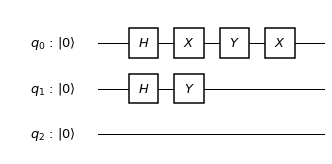

```python
#Studying commutation rules of the quarternion units
import numpy as np
from qiskit import QuantumCircuit, ClassicalRegister, QuantumRegister
from qiskit import execute

q= QuantumRegister(3, 'q')
C= QuantumCircuit(q)
C.h(q[0])
C.x(q[0])
C.y(q[0])
C.h(q[1])
C.y(q[1])
C.x(q[0])

from qiskit.tools.visualization import circuit_drawer

circuit_drawer(C)
```

```python
from qiskit import Aer
backend = Aer.get_backend('statevector_simulator')
job = execute(C, backend)
result = job.result()
outputstate = result.get_statevector(C)
print("simulation: ", result )
print(np.around(outputstate,3))
```

```
simulation:  COMPLETED
[ 0.5-0.j -0.5-0.j -0.5+0.j  0.5-0.j  0. +0.j  0. +0.j  0. +0.j  0. +0.j]
```

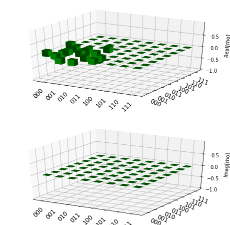

```python
from qiskit.tools.visualization import plot_state
plot_state(outputstate)
```